# iLab 01 - EDA

Nathaniel Evans

October 1, 2018

## **reprohealth EDA**

### How many variables/columns?

There are 9 variables of types character (3) and numeric (6)

```r
summary(data)
```

```
##       year        country           continent            region
##  Min.   :2000   Length:3296        Length:3296        Length:3296
##  1st Qu.:2004   Class :character   Class :character   Class :character
##  Median :2008   Mode  :character   Mode  :character   Mode  :character
##  Mean   :2008
##  3rd Qu.:2011
##  Max.   :2015
##
##  edu_gen_parity    gdp_per_cap          life_exp     mat_mortality
##  Min.   :0.0000   Min.   :   111.4   Min.   :39.76   Min.   :   3.0
##  1st Qu.:0.9653   1st Qu.:  1156.5   1st Qu.:65.56   1st Qu.:  16.0
##  Median :0.9957   Median :  4111.8   Median :74.95   Median :  64.0
##  Mean   :0.9717   Mean   : 13018.6   Mean   :71.96   Mean   : 214.7
##  3rd Qu.:1.0189   3rd Qu.: 15954.6   3rd Qu.:79.06   3rd Qu.: 335.0
##  Max.   :1.2481   Max.   :179308.1   Max.   :87.30   Max.   :2650.0
##  NA's   :1122     NA's   :122        NA's   :139     NA's   :368
##  tot_fertility
##  Min.   :0.827
##  1st Qu.:1.768
##  Median :2.450
##  Mean   :2.989
##  3rd Qu.:4.017
##  Max.   :7.679
##  NA's   :126
```

## How many rows/observations?

There are 3296 rows in this dataset.

```r
n_rows <- data %>% count()
print(n_rows)
```

```
## # A tibble: 1 x 1
##       n
##   <int>
## 1  3296
```

## Which variables are numbers?

The following variables are numeric of type :  
* year  
* edu_gen_parity  
* gdp_per_cap  
* life_exp  
* mat_mortality  
* tot_fertility

```r
data %>% glimpse()
```

```
## Observations: 3,296
## Variables: 9
## $ year           <dbl> 2000, 2001, 2002, 2003, 2004, 2005, 2006, 2007,...
## $ country        <chr> "Afghanistan", "Afghanistan", "Afghanistan", "A...
## $ continent      <chr> "Asia", "Asia", "Asia", "Asia", "Asia", "Asia",...
## $ region         <chr> "Southern Asia", "Southern Asia", "Southern Asi...
## $ edu_gen_parity <dbl> NA, 0.00000, NA, 0.54356, 0.40590, 0.54876, 0.5...
## $ gdp_per_cap    <dbl> NA, 117.4097, 187.8451, 198.7285, 219.1414, 250...
## $ life_exp       <dbl> 56.678, 57.249, 57.849, 58.468, 59.100, 59.730,...
## $ mat_mortality  <dbl> 1100, 1050, 996, 941, 881, 821, 776, 724, 676, ...
## $ tot_fertility  <dbl> 7.494, 7.392, 7.271, 7.136, 6.988, 6.827, 6.651...
```

## Which are categorical variables (numeric or character variables with variables that have a fixed and known set of possible values; aka factor variables)?

The three character types and year have set possible values:  
* year (16) [2000-2015]  
+ technically of type but since it’s a year, they must be ints within bounded possible years (eg no years before XX and no years after 2018 -today!) so it *can* be treated as a factor. Not sure if you’d want to or not though.  
* country (206)  
* continent (5)  
* region (22)

```r
yrs <- data %>% distinct(year) %>% count()
cntry <- data %>% distinct(country) %>% count()
cntnt <- data %>% distinct(continent) %>% count()
rgn <- data %>% distinct(region) %>% count()

print(c("distinct years: ", yrs))
```

```
## [[1]]
## [1] "distinct years: "
##
## $n
## [1] 16
```

```r
print(c("distinct countries: ", cntry))
```

```
## [[1]]
## [1] "distinct countries: "
##
## $n
## [1] 206
```

```r
print(c("distinct continents: ", cntnt))
```

```
## [[1]]
## [1] "distinct continents: "
##
## $n
## [1] 5
```

```r
print(c("distinct regions: ", rgn))
```

```
## [[1]]
## [1] "distinct regions: "
##
## $n
## [1] 22
```

```r
data$year %>% summary()
```

```
##    Min. 1st Qu.  Median    Mean 3rd Qu.    Max.
##    2000    2004    2008    2008    2011    2015
```

Complete this sentence: “There is one row per.” **observation**

```r
head(data)
```

```
## # A tibble: 6 x 9
##    year country continent region edu_gen_parity gdp_per_cap life_exp
##   <dbl> <chr>   <chr>     <chr>           <dbl>       <dbl>    <dbl>
## 1  2000 Afghan~ Asia      South~         NA             NA      56.7
## 2  2001 Afghan~ Asia      South~          0            117.     57.2
## 3  2002 Afghan~ Asia      South~         NA            188.     57.8
## 4  2003 Afghan~ Asia      South~          0.544        199.     58.5
## 5  2004 Afghan~ Asia      South~          0.406        219.     59.1
## 6  2005 Afghan~ Asia      South~          0.549        250.     59.7
## # ... with 2 more variables: mat_mortality <dbl>, tot_fertility <dbl>
```

# Part 2 ——————————-

## Gapminder + new data source

```r
setwd("C:/Users/natha/Documents")
alc <- read_xlsx(("indicator alcohol consumption  20100830.xlsx"),
                      sheet = 1) %>%
                      clean_names() # highly recommended

alc2 <- alc %>%
  rename(country = 1) %>%
  gather(year, x1, -country) %>%
  mutate(year = readr::parse_number(year)) %>%
  filter(!is.na(x1))

glimpse(alc2)
```

```
## Observations: 411
## Variables: 3
## $ country <chr> "Russia", "Russia", "Russia", "Russia", "Russia", "Chi...
## $ year    <dbl> 1985, 1986, 1987, 1988, 1989, 1990, 1990, 1990, 1990, ...
## $ x1      <dbl> 13.31, 10.77, 10.96, 11.57, 12.04, 9.43, 8.40, 12.51, ...
```

### How many variables/columns?

3: chr(1) and dbl(2)

### How many rows/observations?

411 observations (after dropping na’s)

### Which variables are numbers?

year and x1 (alc consumption (Liters))

### Which are categorical variables (numeric or character variables with variables that have a fixed and known set of possible values; aka factor variables)?

Just country.

### Complete this sentence: “There is one row per.”

*observation* or specifically *observation characterizing year, country and avg consumption of alcohol in pop >= 15 yo*

## joining the data (tables)

```r
data_jnd <- left_join(data, alc2)
glimpse(data_jnd)
```

```
## Observations: 3,296
## Variables: 10
## $ year           <dbl> 2000, 2001, 2002, 2003, 2004, 2005, 2006, 2007,...
## $ country        <chr> "Afghanistan", "Afghanistan", "Afghanistan", "A...
## $ continent      <chr> "Asia", "Asia", "Asia", "Asia", "Asia", "Asia",...
## $ region         <chr> "Southern Asia", "Southern Asia", "Southern Asi...
## $ edu_gen_parity <dbl> NA, 0.00000, NA, 0.54356, 0.40590, 0.54876, 0.5...
## $ gdp_per_cap    <dbl> NA, 117.4097, 187.8451, 198.7285, 219.1414, 250...
## $ life_exp       <dbl> 56.678, 57.249, 57.849, 58.468, 59.100, 59.730,...
## $ mat_mortality  <dbl> 1100, 1050, 996, 941, 881, 821, 776, 724, 676, ...
## $ tot_fertility  <dbl> 7.494, 7.392, 7.271, 7.136, 6.988, 6.827, 6.651...
## $ x1             <dbl> NA, NA, NA, NA, NA, 0.02, NA, NA, 0.03, NA, NA,...
```

# Part 3 ———————-

### “Your goal during EDA is to develop an understanding of your data. The easiest way to do this is to use questions as tools to guide your investigation.EDA is fundamentally a creative process. And like most creative processes, the key to asking quality questions is to generate a large quantity of questions.”

# task 1

## How does [alcohol consumption] (x1) vary across different continents?

```r
# what years does this include?
data_jnd %>% filter(!is.na(x1), !is.na(gdp_per_cap)) %>% select(year) %>% summary()
```

```
##       year
##  Min.   :2000
##  1st Qu.:2005
##  Median :2005
##  Mean   :2006
##  3rd Qu.:2008
##  Max.   :2008
```

```r
# lets create median of the years available
data3 <- data_jnd %>% filter(!is.na(x1), !is.na(gdp_per_cap)) %>% group_by(continent) %>% summarize(med_x1 = median(x1), med_gdp = median(gdp_per_cap))
# get rid of med_gdp, we'll use that next. Generate table
dg <- data3 %>% select(-med_gdp)
dg
```

```
## # A tibble: 5 x 2
##   continent med_x1
##   <chr>      <dbl>
## 1 Africa      3.78
## 2 Americas    6.91
## 3 Asia        2.47
## 4 Europe     12.5
## 5 Oceania     3.71
```

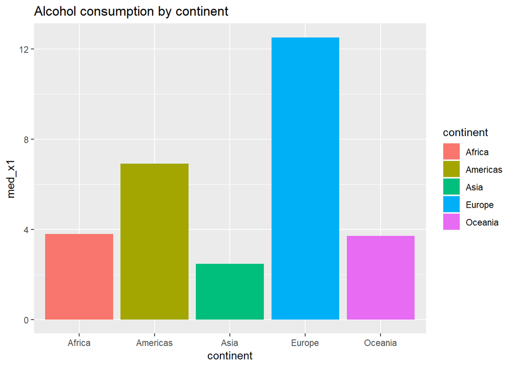

```r
#plot a bar plot
dg %>% ggplot(aes(x=continent, y=med_x1, fill= continent)) + geom_col() + ggtitle("Alcohol consumption by continent")
```

## task 2 : how do countries alcohol consumption change over time?

Find countries with interesting stories. Open-ended and, therefore, hard. Promising but unsuccessful attempts are encouraged. This will generate interesting questions to follow up on in class.

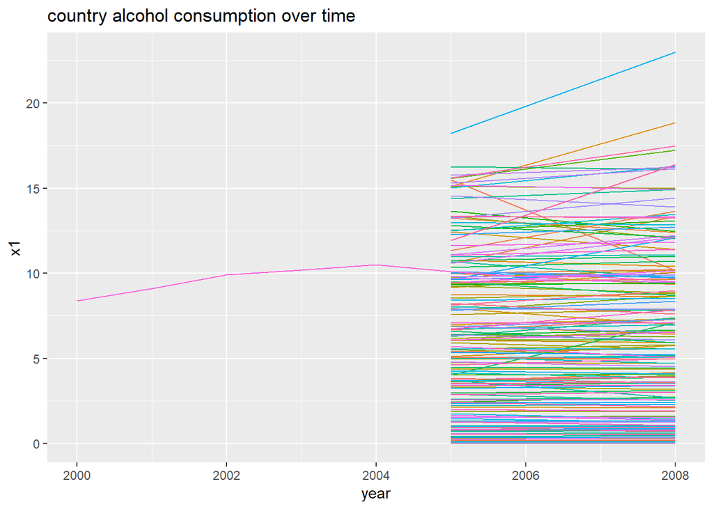

```r
data4 <-  data_jnd %>% filter(!is.na(x1), !is.na(gdp_per_cap)) %>% group_by(country)
data4 %>% ggplot(aes(x=year, y=x1, color=country)) + geom_line() + ggtitle("country alcohol consumption over time") + theme(legend.position = "none")
```

Whoops! But very interesting, we only have one country with data from 2000 to 2008, the rest only span from 2005 - 2008. I’ll filter to only include 2005-2008. Also, there are way too many countries to compare this way, so we’ll filter to just Africa. Lastly, there is very little change over the years in countries with x1 less than 5 so we’ll only include countries with x1 > 5.

```r
head(data4)
```

```
## # A tibble: 6 x 10
## # Groups:   country [3]
##    year country continent region edu_gen_parity gdp_per_cap life_exp
##   <dbl> <chr>   <chr>     <chr>           <dbl>       <dbl>    <dbl>
## 1  2005 Afghan~ Asia      South~          0.549        250.     59.7
## 2  2008 Afghan~ Asia      South~          0.590        373.     61.5
## 3  2005 Albania Europe    South~          0.964       2709.     78.2
## 4  2008 Albania Europe    South~          0.984       4371.     78.7
## 5  2005 Algeria Africa    North~          0.999       3100.     74.1
## 6  2008 Algeria Africa    North~          0.986       4905.     75.3
## # ... with 3 more variables: mat_mortality <dbl>, tot_fertility <dbl>,
## #   x1 <dbl>
```

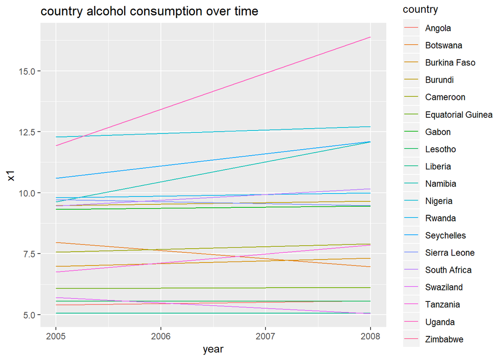

```r
data4 %>% filter(year>=2005, continent=='Africa', x1>5) %>% ggplot(aes(x=year, y=x1, color=country)) + geom_line() + ggtitle("country alcohol consumption over time")
```

This didn’t come out quite as nice as I’d hoped but there are some notable countries, in particular, Uganda, that top pink line, had a significant increase in alcohol consumption. To dig into that a little more…

```r
ug_data <- data4 %>% filter(country=="Uganda")
ug_data %>% glimpse()
```

```
## Observations: 2
## Variables: 10
## $ year           <dbl> 2005, 2008
## $ country        <chr> "Uganda", "Uganda"
## $ continent      <chr> "Africa", "Africa"
## $ region         <chr> "Eastern Africa", "Eastern Africa"
## $ edu_gen_parity <dbl> NA, NA
## $ gdp_per_cap    <dbl> 315.7880, 449.6928
## $ life_exp       <dbl> 54.381, 57.177
## $ mat_mortality  <dbl> 504, 451
## $ tot_fertility  <dbl> 6.583, 6.337
## $ x1             <dbl> 11.93, 16.40
```

This table shows that the only other significant increase over these two observations were gdp_per_cap, which actually makes sense; I would expect that as gdp increases, so does alcohol consumption.

## task 3 - does alc consumption correllate to gdp_per_cap?

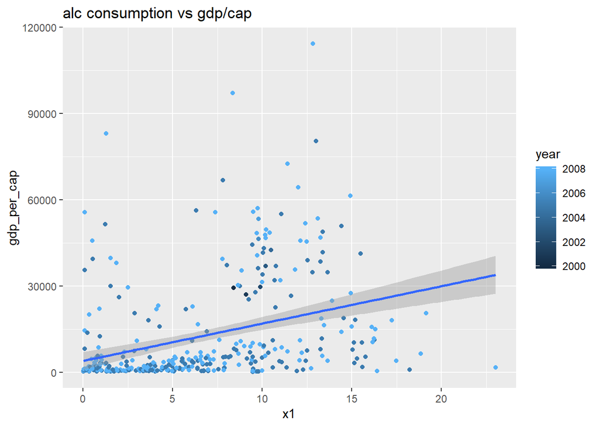

```r
data4 %>% ggplot(aes(x=x1, y=gdp_per_cap, color=year)) + geom_point() + ggtitle("alc consumption vs gdp/cap") +  geom_smooth(method='lm')
```

```r
mod <- lm(formula=x1~gdp_per_cap, data=data4)
summary(mod)
```

```
##
## Call:
## lm(formula = x1 ~ gdp_per_cap, data = data4)
##
## Residuals:
##      Min       1Q   Median       3Q      Max
## -11.4991  -3.4367  -0.3948   2.6098  17.3276
##
## Coefficients:
##              Estimate Std. Error t value Pr(>|t|)
## (Intercept) 5.534e+00  2.935e-01   18.85  < 2e-16 ***
## gdp_per_cap 8.744e-05  1.319e-05    6.63 1.31e-10 ***
## ---
## Signif. codes:  0 '***' 0.001 '**' 0.01 '*' 0.05 '.' 0.1 ' ' 1
##
## Residual standard error: 4.502 on 343 degrees of freedom
## Multiple R-squared:  0.1136, Adjusted R-squared:  0.111
## F-statistic: 43.95 on 1 and 343 DF,  p-value: 1.307e-10
```

It looks like there is weak correlation, but a residual analysis is definitely needed and I ’d guess that there really isn’t much predictive value in this model. However, it does seem like there may be two different groupings of this data that follow more predicatble trends, simply, data above the fitted line and data below the fitted line might have better predictive succuess if they could be separated by another variable.

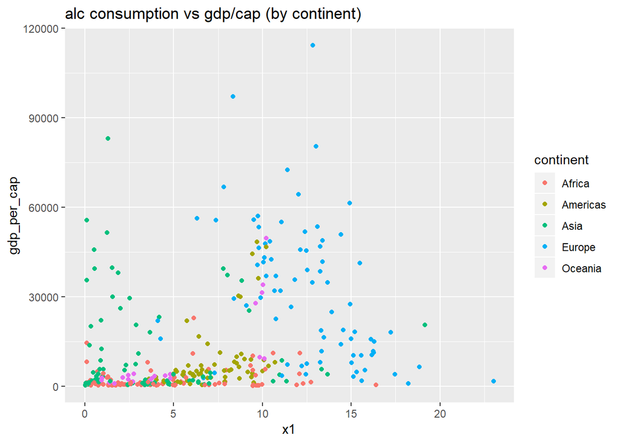

```r
data4 %>% ggplot(aes(x=x1, y=gdp_per_cap, color=continent)) + geom_point() + ggtitle("alc consumption vs gdp/cap (by continent)")
```

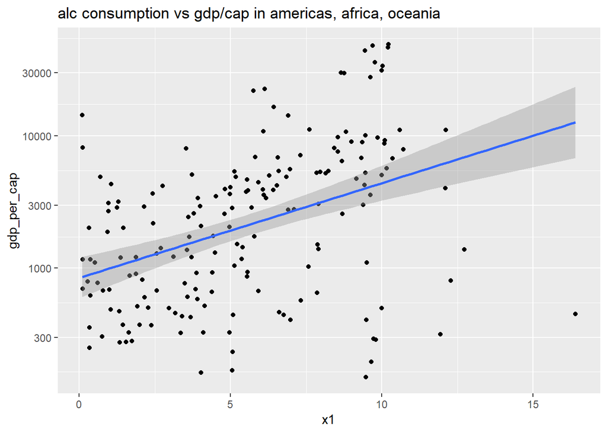

```r
# remove europe
data4 %>% filter(continent != "Europe", continent != "Asia") %>% ggplot(aes(x=x1, y=gdp_per_cap)) + geom_point() + ggtitle("alc consumption vs gdp/cap in americas, africa, oceania") +  geom_smooth(method='lm') + scale_y_log10()
```

Coloring the plot by continent shows that a significant portion of the outlying data is from Europe and Asia, and by removing those, it *looks* like there is increased correllation, and more importantly a linear model would have more predictive value. Additionally, by scaling gdp_per_cap by log10, it creates a better distribution of values and shows the trend. There are a great number of reasons that could account for this, I’d hazard that the most likely reasons stem from culture and/or production.

Credit to Justine and Alfonso for explaining how to get rmarkdown to add line breaks. I was going nuts trying to figure that out.